# Russo-Ukrainian War

25 September, 2022

Inspired by the data sets collected by [Lena Sokol’s Kaggle site](https://www.kaggle.com/code/sokolheavy/2022-ukraine-russia-war-visualization) and [Petro Ivanyuk’s Kaggle site.](https://www.kaggle.com/datasets/piterfm/2022-ukraine-russian-war)

# 1 Russo-Ukrainian War

The Russo-Ukrainian War is an ongoing war between Russia (together with pro-Russian separatist forces) and Ukraine.[e] It was started by Russia in February 2014 following the Ukrainian Revolution of Dignity, and initially focused on the status of Crimea and the Donbas, internationally recognised as part of Ukraine. The first eight years of the conflict included the Russian annexation of Crimea (2014) and the war in Donbas (2014–present) between Ukraine and Russian-backed separatists, as well as naval incidents, cyberwarfare, and political tensions. Following a Russian military build-up on the Russia–Ukraine border from late 2021, the conflict expanded significantly when Russia launched a full-scale invasion of Ukraine on 24 February 2022. From [Wikipedia](https://en.wikipedia.org/wiki/Russo-Ukrainian_War#2022_Russian_invasion_of_Ukraine)

[figure not shown]

# 2 Russian Casualties

```r
# Load data Russian casualties
russia_losses_personnel <- read_csv("data/russia_losses_personnel.csv")
```

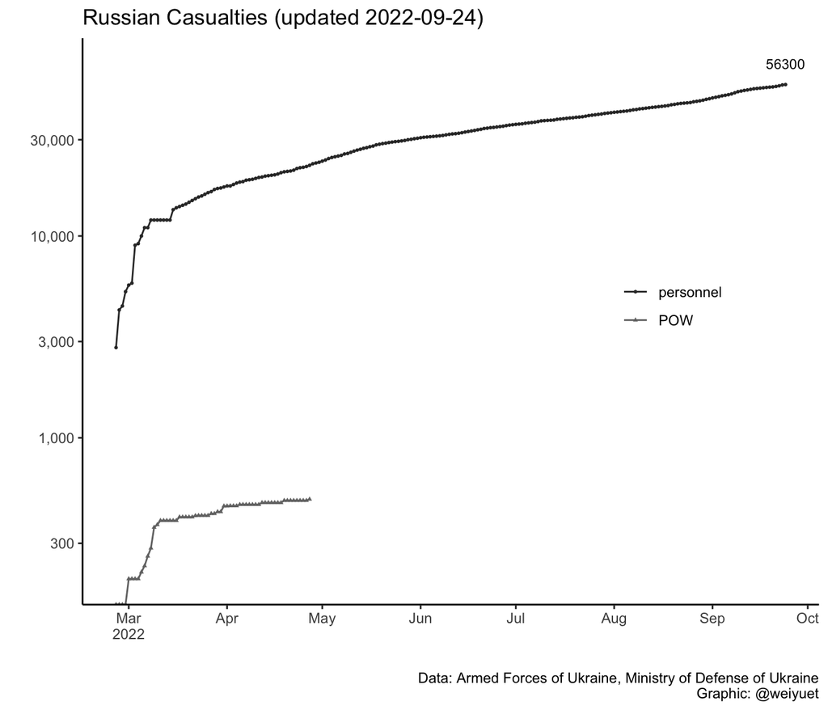

```r
# Change data to long format
russia_losses_personnel_long <-  russia_losses_personnel %>%
  pivot_longer(cols = c(personnel, POW), names_to = "casualties", values_to = "value")

# Plot Russian casualties
russia_losses_personnel_long %>%
  drop_na() %>%
  ggplot(aes(x = date, y = value, colour = casualties)) +
  geom_line() +
  geom_point(aes(shape = casualties), size = 0.7) +
  scale_x_date(date_breaks = "1 month", labels = label_date_short()) +
  scale_y_log10(labels = label_number(big.mark = ",")) +
  annotate(
    geom = "text",
    x = as.Date(glue("{max(russia_losses_personnel$date)}")),
    y = max(russia_losses_personnel$personnel) + 15000, label = glue("{max(russia_losses_personnel$personnel)}"), size = 3
  ) + # peak
  theme_classic() +
  theme(legend.position = c(0.8, 0.55)) +
  scale_colour_grey(start = 0.2, end = 0.45) +
  labs(
    x = "", y = "",
    colour = "", shape = "",
    title = glue("Russian Casualties (updated {max(russia_losses_personnel$date)})"),
    caption = "Data: Armed Forces of Ukraine, Ministry of Defense of Ukraine\nGraphic: @weiyuet"
  )
```

# 3 Russian Equipment Losses

```r
# Load data Russian equipment
russia_losses_equipment <- read_csv("data/russia_losses_equipment.csv")
```

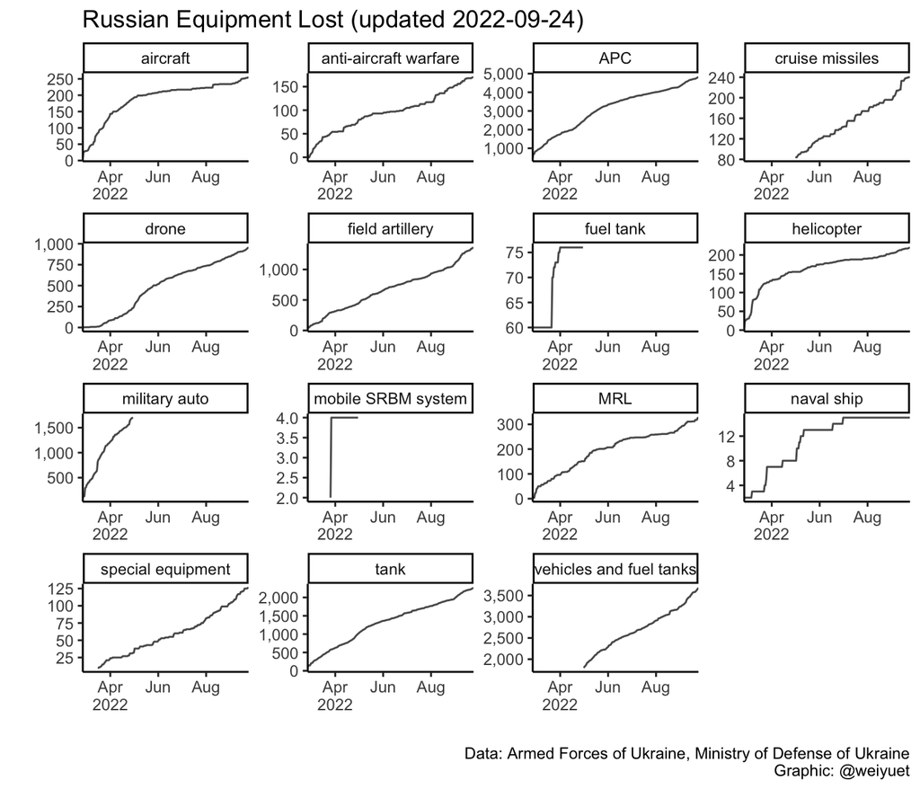

```r
# Change data to long format
russia_losses_equipment_long <- russia_losses_equipment %>%
  select(-"greatest losses direction") %>%
  pivot_longer(cols = c(aircraft:`cruise missiles`),
               names_to = "equipment", values_to = "value")

# Plot Russian equipment losses
russia_losses_equipment_long %>%
  ggplot(aes(x = date, y = value, colour = equipment)) +
  geom_line(colour = "gray35") +
  facet_wrap(~equipment, scales = "free") +
  scale_x_date(date_breaks = "2 month", labels = label_date_short(),
               expand = c(0,0)) +
  scale_y_continuous(labels = label_number(big.mark = ",")) +
  theme_classic() +
  theme(legend.position = "none") +
  labs(
    x = "", y = "",
    title = glue("Russian Equipment Lost (updated {max(russia_losses_equipment$date)})"),
    caption = "Data: Armed Forces of Ukraine, Ministry of Defense of Ukraine\nGraphic: @weiyuet"
  )
```

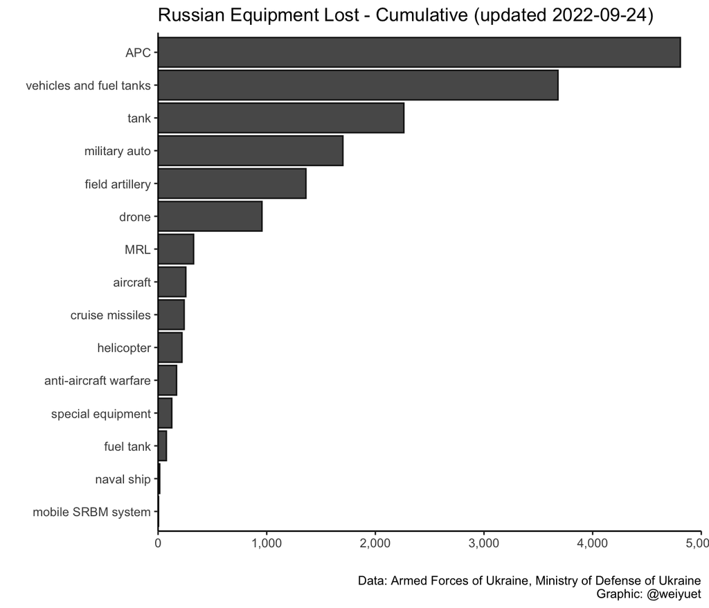

```r
# Plot Russian equipment losses cumulative
russia_losses_equipment_long %>%
  group_by(equipment) %>%
  summarise(cumulative_total = max(value, na.rm = TRUE)) %>%
  mutate(equipment = fct_reorder(equipment, cumulative_total)) %>%
  ggplot(aes(x = cumulative_total, y = equipment)) +
  geom_col(colour = "gray10", fill = "gray35") +
  scale_x_continuous(
    labels = label_number(big.mark = ","),
    breaks = seq(0, 5000, 1000),
    limits = c(0, 5000),
    expand = c(0, 0)
  ) +
  theme_classic() +
  labs(
    x = "", y = "",
    title = glue("Russian Equipment Lost - Cumulative (updated {max(russia_losses_equipment$date)})"),
    caption = "Data: Armed Forces of Ukraine, Ministry of Defense of Ukraine\nGraphic: @weiyuet")
```

# 4 Russian Crude Oil Production compared to Ukraine, Saudi Arabia, Norway, the USA, and the EU

Crude oil production is defined as the quantities of oil extracted from the ground after the removal of inert matter or impurities. It includes crude oil, natural gas liquids (NGLs) and additives. This indicator is measured in thousand tonne of oil equivalent (TOE).

[OECD Data](https://data.oecd.org/energy/crude-oil-production.htm)

```r
# Load data
crude_oil_production_annual <- read_csv("data/crude_oil_production_annual.csv")
```

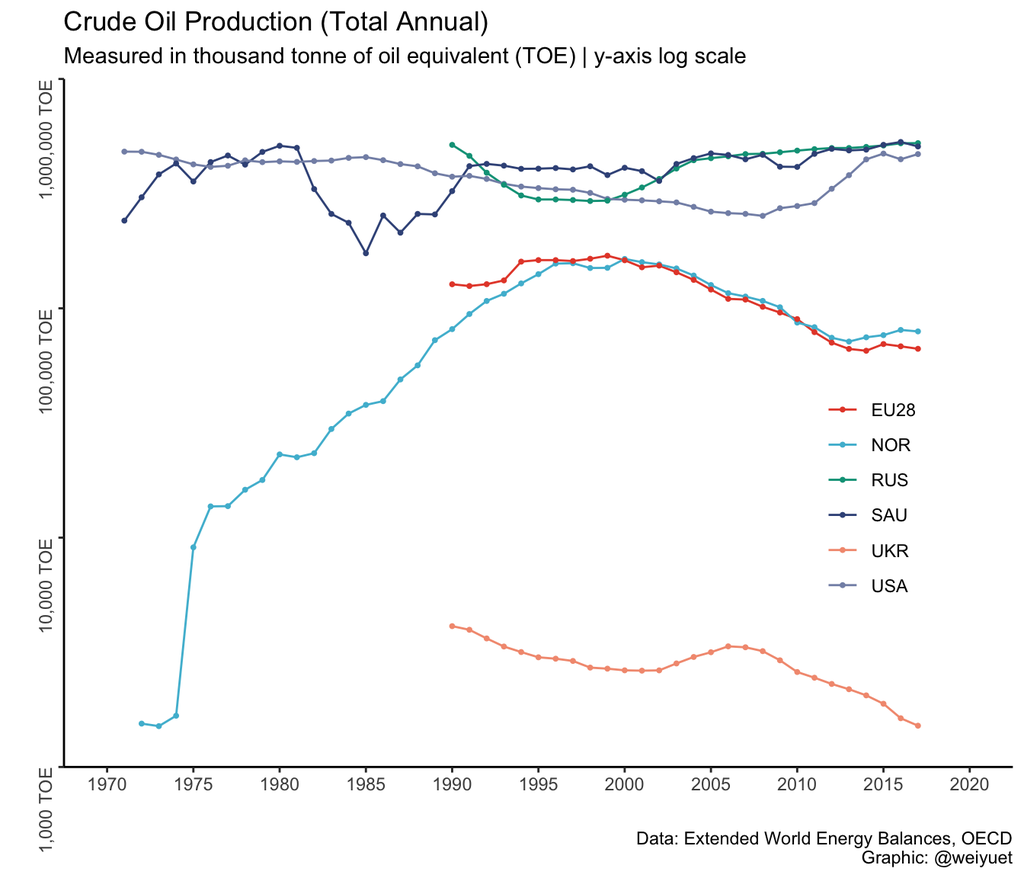

```r
# Plot Crude oil production in Russia, compared to Ukraine, Saudi Arabia, Norway, and the EU
countries_to_include <- c("RUS", "UKR", "SAU", "NOR", "USA", "EU28")

crude_oil_production_annual %>%
  filter(LOCATION %in% countries_to_include) %>%
  ggplot(aes(x = TIME, y = Value, colour = LOCATION)) +
  geom_line() +
  geom_point(size = 0.7) +
  scale_x_continuous(breaks = seq(1970, 2020, 5),
                     limits = c(1970, 2020)) +
  scale_y_log10(labels = label_number(suffix = " TOE", big.mark = ","),
                expand = c(0, 0),
                limits = c(1000, 1000000)) +
  theme_classic() +
  theme(legend.position = c(0.85, 0.4),
        legend.title = element_blank(),
        axis.text.y = element_text(angle = 90)) +
  scale_colour_npg() +
  labs(x = "", y = "",
       title = "Crude Oil Production (Total Annual)",
       subtitle = "Measured in thousand tonne of oil equivalent (TOE) | y-axis log scale",
       caption = "Data: Extended World Energy Balances, OECD\nGraphic: @weiyuet")
```